# Analiza sentymentu i tematów artykułów finansowych dotyczących spółek notowanych na Giełdzie Papierów Wartościowych w Warszawie

Projekt zaliczeniowy

Natalia Liszniańska, Mateusz Izydorczyk, Franciszek Zabłocki

# 1 Wprowadzenie

Celem projektu jest zbudowanie pipeline’u automatycznej analizy tekstów finansowych z serwisu bankier.pl, który dla każdej spółki notowanej na Giełdzie Papierów Wartościowych w Warszawie (GPW) wyciąga sygnał sentymentu medialnego oraz identyfikuje główne tematy poruszane w artykułach. Praca powstała w ramach przedmiotu *Projektowanie Systemów Informatycznych* (PSI) na semestr 2026.

Źródłem danych są artykuły scrapowane z bankier.pl - zarówno bieżące przez RSS, jak i historyczne przez archiwum portalu. Tickery spółek GPW przypisywane są automatycznie do każdego artykułu na podstawie wykrywania wystąpień nazw firm i symboli giełdowych w tekście (skrypt `src/data_ingestion/assign_tickers.R`).

Zastosowano pięć technik analizy tekstu: (1) leksykonową analizę sentymentu opartą na zhybrydyzowanym słowniku polskim (LM-PL + plWordNet + słownik własny), (2) klastrowanie k-means (hard clustering) na bazie macierzy TF-IDF, (3) modelowanie tematyczne LDA (Latent Dirichlet Allocation, soft clustering), (4) profile semantyczne spółek metodą TF-IDF oraz (5) analizę częstości słów wraz z chmurą słów. Raport prezentuje wyniki - kod analizy znajduje się w `src/sentiment.R` oraz `src/clustering.R`.

# 2 Dane i preprocessing

Pipeline danych obejmuje następujące etapy: pobranie listy artykułów (RSS + archive) → scraping treści → parsowanie HTML do czystego tekstu → przypisanie tickerów GPW → lematyzacja tekstu modelem udpipe (`polish-pdb-ud-2.5`).

Słowniki sentymentu stanowią hybrydę trzech źródeł:

- plWordNet emo - ogólnotematyczny słownik emocji dla języka polskiego, po parsowaniu z dumpu SQL i mappingu POS do UD: 18 884 wpisów (NOUN/VERB/ADJ/ADV, sentiment positive/negative),
- Loughran-McDonald PL - finansowy słownik LM przetłumaczony przez DeepL API + lematyzacja udpipe + filtr open-class POS + manual review top-50 (dropping mistranslated prefixed terms): 2 206 wpisów (kategorie: positive, negative, uncertainty, litigious, constraining),
- Custom PL - własny minisłownik specyficzny dla domeny GPW (hossa/bessa/rajd, dywidenda/inwestycja, frankowicze/KNF/WIBOR itd.): 162 wpisy, najwyższy priorytet (override LM_PL i plWN).

Stopwords to lista `stopwords-iso` dla języka polskiego (~342 słowa) rozszerzona o 38 słów domenowych: 22 neutralne biznesowe (np. *artykuł*, *informacja*, *komunikat*) oraz 16 artefaktów scrapingu (rozszerzenia plików: `xhtml`, `xades`, `pdf`, `xls`, `html` itd.). Dodatkowo filtr w pipeline odrzuca tokeny zawierające bajty mojibake z niepoprawnie odkodowanych załączników ESPI.

```r
safe_chunk({
  library(lubridate)
  # Read as nested list (NOT simplifyDataFrame) - manifest has list-column `tickers`.
  manifest <- if (file.exists(constants$processed_manifest_file)) {
    jsonlite::fromJSON(constants$processed_manifest_file, simplifyVector = FALSE)
  } else NULL
  dates <- safe_read_csv(constants$article_dates, "article_dates")
  tokens <- if (file.exists(constants$lemmatized_tokens_cache)) {
    readRDS(constants$lemmatized_tokens_cache)
  } else NULL

  n_articles <- if (!is.null(manifest)) length(manifest) else NA_integer_

  date_range <- if (!is.null(dates)) {
    d <- suppressWarnings(ymd_hm(dates$publication_date, quiet = TRUE))
    d <- as.Date(d)
    d <- d[!is.na(d)]
    if (length(d) > 0) sprintf("%s - %s", min(d), max(d)) else "n/d"
  } else "n/d"

  # Unique tickers attributed to at least one article (from processed manifest)
  n_tickers <- if (!is.null(manifest)) {
    ts <- unlist(lapply(manifest, function(x) {
      if (length(x$tickers) == 0) character(0)
      else vapply(x$tickers, function(t) t$ticker, character(1))
    }))
    length(unique(ts))
  } else NA_integer_

  # Articles with at least one ticker
  n_with_ticker <- if (!is.null(manifest)) {
    sum(vapply(manifest, function(x) length(x$tickers) > 0, logical(1)))
  } else NA_integer_

  # Mean article length in tokens (lemmatized - proxy for length).
  mean_tokens <- if (!is.null(tokens)) {
    counts <- tokens |> dplyr::count(.data$article_id, name = "n_tokens")
    round(mean(counts$n_tokens))
  } else NA_integer_

  total_tokens <- if (!is.null(tokens)) nrow(tokens) else NA_integer_

  summary_tbl <- data.frame(
    Metryka = c("Liczba artykułów",
                "Zakres dat (publikacja)",
                "Artykuły z przypisanym tickerem",
                "Liczba unikalnych tickerów (z manifestu)",
                "Łączna liczba tokenów (po lematyzacji)",
                "Średnia liczba tokenów / artykuł"),
    Wartość = c(fmt_int(n_articles),
                date_range,
                ifelse(is.na(n_with_ticker), "n/d",
                       sprintf("%s (%.0f%%)", fmt_int(n_with_ticker),
                               100 * n_with_ticker / max(n_articles, 1))),
                ifelse(is.na(n_tickers), "n/d", fmt_int(n_tickers)),
                ifelse(is.na(total_tokens), "n/d", fmt_int(total_tokens)),
                ifelse(is.na(mean_tokens), "n/d", fmt_int(mean_tokens)))
  )
  knitr::kable(summary_tbl, caption = "Podsumowanie korpusu artykułów")
})
```

Podsumowanie korpusu artykułów

| Metryka | Wartość |
| --- | --- |
| Liczba artykułów | 9 666 |
| Zakres dat (publikacja) | 2019-09-27 - 2026-05-17 |
| Artykuły z przypisanym tickerem | 2 302 (24%) |
| Liczba unikalnych tickerów (z manifestu) | 59 |
| Łączna liczba tokenów (po lematyzacji) | 3 830 838 |
| Średnia liczba tokenów / artykuł | 411 |

# 3 Analiza częstości słów

## 3.1 Top 30 najczęstszych słów

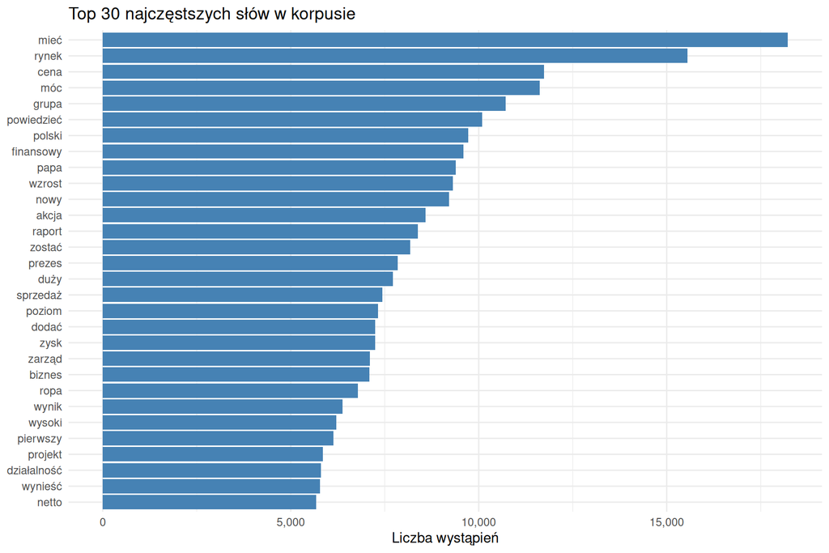

```r
safe_chunk({
  wf <- safe_read_csv(constants$word_freq, "word_freq")
  if (is.null(wf)) {
    cat("Brak danych word_freq.csv - uruchom pipeline tokenizacji.\n")
  } else {
    top30 <- wf %>%
      arrange(desc(freq)) %>%
      head(30) %>%
      mutate(word = factor(word, levels = rev(word)))

    ggplot(top30, aes(x = word, y = freq)) +
      geom_col(fill = "steelblue") +
      coord_flip() +
      scale_y_continuous(labels = scales::comma) +
      labs(
        title = "Top 30 najczęstszych słów w korpusie",
        x = NULL,
        y = "Liczba wystąpień"
      ) +
      theme_minimal()
  }
})
```

## 3.2 Wordcloud globalny

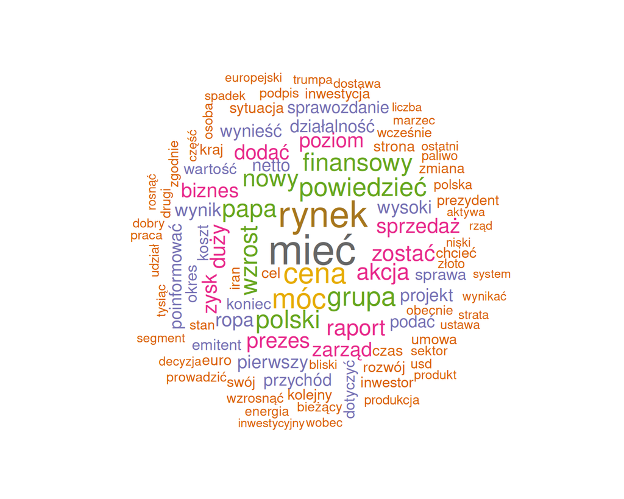

```r
safe_chunk({
  path <- file.path(constants$figures_directory, "wordcloud_global.png")
  if (!file.exists(path)) {
    cat("Brak pliku", path, "- wygeneruj wordcloud w pipeline.\n")
  } else {
    knitr::include_graphics(path)
  }
})
```

# 4 Analiza sentymentu

## 4.1 Chmury słów: pozytywne vs negatywne

Słowa które najczęściej dostały etykietę `positive` (zielone) vs `negative` (czerwone) w korpusie. Wizualizacja kontrastu finansowego sentymentu.

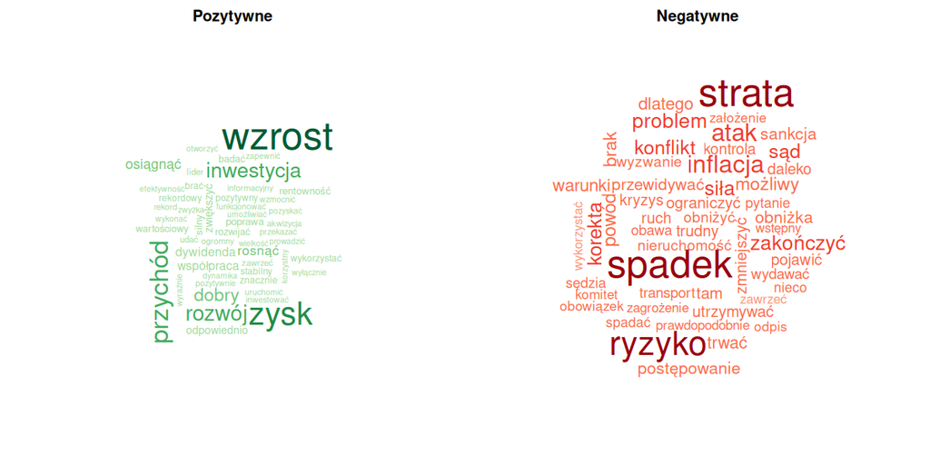

```r
safe_chunk({
  path <- file.path(constants$figures_directory, "wordcloud_sentiment.png")
  if (file.exists(path)) knitr::include_graphics(path)
  else cat("Brak figury wordcloud_sentiment.png.\n")
})
```

## 4.2 Chmury słów per kategoria LM

Loughran-McDonald-style kategorie: `positive`, `negative`, `uncertainty` (niepewność), `litigious` (prawne), `constraining` (regulacyjne). Pokazuje semantyczny krajobraz każdej kategorii w korpusie bankier.pl.

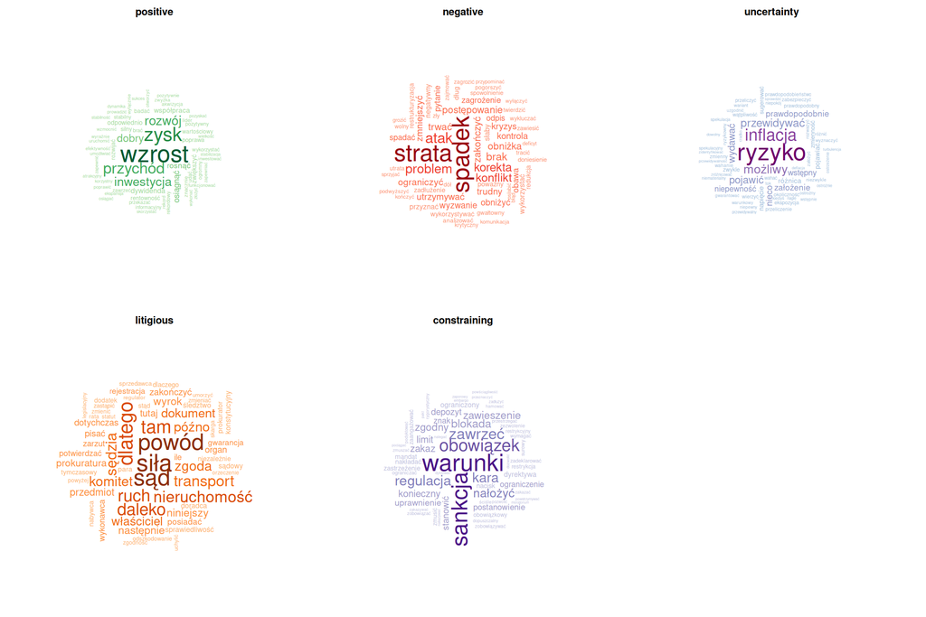

```r
safe_chunk({
  suppressPackageStartupMessages({
    library(wordcloud); library(RColorBrewer)
  })
  source("src/common/text_pipeline.R")
  tokens <- if (file.exists(constants$lemmatized_tokens_cache)) {
    readRDS(constants$lemmatized_tokens_cache)
  } else NULL
  lex <- tryCatch(load_sentiment_lexicon(), error = function(e) NULL)
  if (is.null(tokens) || is.null(lex)) {
    cat("Brak danych - uruchom pipeline.\n")
  } else {
    matched <- tokens |>
      inner_join(lex |> filter(.data$pos != "ANY"), by = c("lemma", "pos"))
    cats <- c("positive", "negative", "uncertainty", "litigious", "constraining")
    palettes <- c(positive = "Greens", negative = "Reds",
                  uncertainty = "BuPu", litigious = "Oranges", constraining = "Purples")

    par(mfrow = c(2, 3), mar = c(1, 1, 2, 1))
    for (cat_name in cats) {
      sub <- matched |>
        filter(.data$category == cat_name) |>
        count(.data$lemma, sort = TRUE, name = "freq") |>
        head(60)
      if (nrow(sub) == 0) {
        plot.new(); title(paste(cat_name, "(brak)"))
        next
      }
      tryCatch({
        wordcloud(sub$lemma, sub$freq, min.freq = 1, max.words = 60,
                  scale = c(2.8, 0.4), random.order = FALSE, rot.per = 0.2,
                  colors = brewer.pal(8, palettes[[cat_name]])[4:8])
        title(cat_name, line = 0.5)
      }, error = function(e) {
        plot.new(); title(paste(cat_name, "(err)"))
      })
    }
    plot.new()  # 6th cell empty
  }
})
```

## 4.3 Ranking spółek (per ticker)

Wartość `mean_score` to średnia z znormalizowanych wyników sentymentu artykułów przypisanych do danej spółki. Tickery z `n_articles_with_signal = 0` (brak słów sentymentowych w artykułach) zostały odfiltrowane z wykresu rankingu i pokazane osobno.

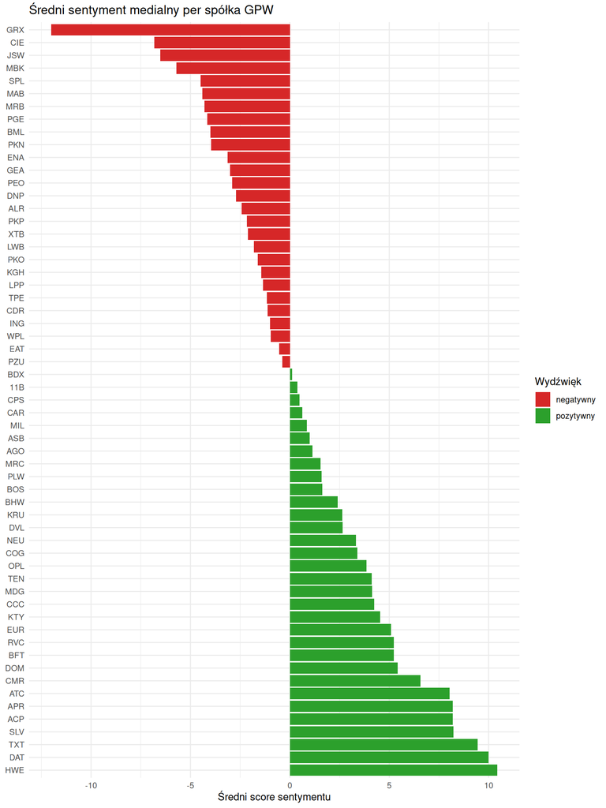

```r
safe_chunk({
  spt <- safe_read_csv(constants$sentiment_per_ticker, "sentiment_per_ticker")
  if (is.null(spt)) {
    cat("Brak danych sentiment_per_ticker.csv.\n")
  } else {
    spt_signal <- spt %>%
      filter(n_articles_with_signal > 0) %>%
      arrange(desc(mean_score)) %>%
      mutate(
        ticker = factor(ticker, levels = ticker),
        sign = ifelse(mean_score >= 0, "pozytywny", "negatywny")
      )

    ggplot(spt_signal, aes(x = ticker, y = mean_score, fill = sign)) +
      geom_col() +
      scale_fill_manual(values = c("pozytywny" = "#2ca02c", "negatywny" = "#d62728")) +
      coord_flip() +
      labs(
        title = "Średni sentyment medialny per spółka GPW",
        x = NULL,
        y = "Średni score sentymentu",
        fill = "Wydźwięk"
      ) +
      theme_minimal(base_size = 11)
  }
})
```

```r
safe_chunk({
  spt <- safe_read_csv(constants$sentiment_per_ticker, "sentiment_per_ticker")
  if (is.null(spt)) {
    cat("Brak danych.\n")
  } else {
    spt_signal <- spt %>% filter(n_articles_with_signal > 0)
    top5_pos <- spt_signal %>% arrange(desc(mean_score)) %>% head(5)
    top5_neg <- spt_signal %>% arrange(mean_score) %>% head(5)

    cat("\nTop 5 spółek o najpozytywniejszym sentymencie:\n\n")
    print(knitr::kable(top5_pos, digits = 3))
    cat("\nTop 5 spółek o najnegatywniejszym sentymencie:\n\n")
    print(knitr::kable(top5_neg, digits = 3))

    no_signal <- spt %>% filter(n_articles_with_signal == 0)
    if (nrow(no_signal) > 0) {
      cat(sprintf("\nSpółki bez sygnału sentymentu (%d): %s\n",
                  nrow(no_signal),
                  paste(no_signal$ticker, collapse = ", ")))
    }
  }
})
```

Top 5 spółek o najpozytywniejszym sentymencie:

| ticker | mean_score | n_articles | n_articles_with_signal | articles_pos | articles_neg |
| --- | --- | --- | --- | --- | --- |
| HWE | 10.429 | 7 | 7 | 4 | 2 |
| DAT | 10.000 | 4 | 3 | 2 | 1 |
| TXT | 9.444 | 9 | 9 | 9 | 0 |
| SLV | 8.222 | 18 | 18 | 12 | 6 |
| ACP | 8.190 | 43 | 42 | 29 | 10 |

Top 5 spółek o najnegatywniejszym sentymencie:

| ticker | mean_score | n_articles | n_articles_with_signal | articles_pos | articles_neg |
| --- | --- | --- | --- | --- | --- |
| GRX | -12.000 | 4 | 4 | 1 | 3 |
| CIE | -6.818 | 11 | 11 | 2 | 9 |
| JSW | -6.528 | 91 | 89 | 14 | 69 |
| MBK | -5.700 | 40 | 40 | 15 | 25 |
| SPL | -4.492 | 67 | 59 | 19 | 35 |

## 4.4 Pokrycie spółek: liczba artykułów i rozkład w czasie

Które spółki są najczęściej omawiane w korpusie i jak ich pokrycie medialne rozkłada się w czasie. Liczba artykułów per spółka wpływa na wiarygodność rankingu sentymentu - spółki z kilkoma artykułami mają zaszumiony `mean_score`.

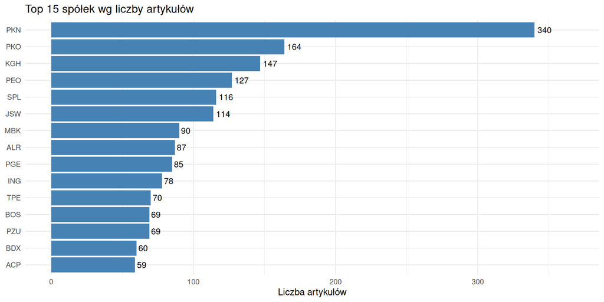

```r
safe_chunk({
  manifest <- if (file.exists(constants$processed_manifest_file)) {
    jsonlite::fromJSON(constants$processed_manifest_file, simplifyVector = FALSE)
  } else NULL
  if (is.null(manifest)) {
    cat("Brak manifestu.\n")
  } else {
    rows <- do.call(rbind, lapply(manifest, function(x) {
      if (length(x$tickers) == 0) return(NULL)
      do.call(rbind, lapply(x$tickers, function(t) {
        data.frame(article_id = x$id, ticker = t$ticker, stringsAsFactors = FALSE)
      }))
    }))
    counts <- rows %>% count(ticker, sort = TRUE) %>% head(15) %>%
      mutate(ticker = factor(ticker, levels = rev(ticker)))

    ggplot(counts, aes(x = ticker, y = n)) +
      geom_col(fill = "steelblue") +
      geom_text(aes(label = n), hjust = -0.2, size = 3.5) +
      coord_flip() +
      labs(title = "Top 15 spółek wg liczby artykułów",
           x = NULL, y = "Liczba artykułów") +
      theme_minimal(base_size = 11) +
      expand_limits(y = max(counts$n) * 1.08)
  }
})
```

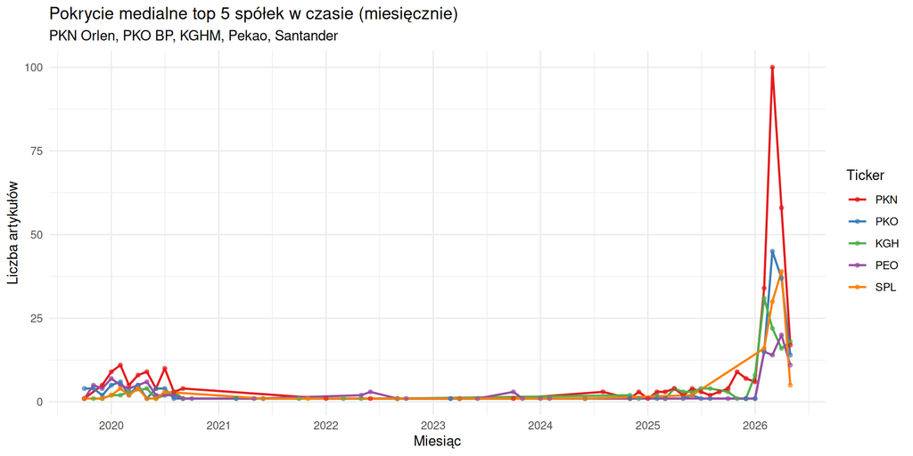

```r
safe_chunk({
  library(lubridate)
  manifest <- if (file.exists(constants$processed_manifest_file)) {
    jsonlite::fromJSON(constants$processed_manifest_file, simplifyVector = FALSE)
  } else NULL
  dates <- safe_read_csv(constants$article_dates, "article_dates")
  if (is.null(manifest) || is.null(dates)) {
    cat("Brak danych.\n")
  } else {
    rows <- do.call(rbind, lapply(manifest, function(x) {
      if (length(x$tickers) == 0) return(NULL)
      do.call(rbind, lapply(x$tickers, function(t) {
        data.frame(article_id = x$id, ticker = t$ticker, stringsAsFactors = FALSE)
      }))
    }))
    top5 <- rows %>% count(ticker, sort = TRUE) %>% head(5) %>% pull(ticker)

    coverage <- rows %>%
      filter(ticker %in% top5) %>%
      inner_join(dates, by = "article_id") %>%
      mutate(d = suppressWarnings(ymd_hm(publication_date, quiet = TRUE)),
             period = floor_date(as.Date(d), "month")) %>%
      filter(!is.na(period)) %>%
      count(ticker, period, name = "n") %>%
      mutate(ticker = factor(ticker, levels = top5))

    ggplot(coverage, aes(x = period, y = n, color = ticker)) +
      geom_line(linewidth = 0.8) +
      geom_point(size = 1.2, alpha = 0.6) +
      scale_color_brewer(palette = "Set1") +
      scale_x_date(date_breaks = "1 year", date_labels = "%Y") +
      labs(title = "Pokrycie medialne top 5 spółek w czasie (miesięcznie)",
           subtitle = "PKN Orlen, PKO BP, KGHM, Pekao, Santander",
           x = "Miesiąc", y = "Liczba artykułów", color = "Ticker") +
      theme_minimal(base_size = 11)
  }
})
```

## 4.5 Sentyment per artykuł

Rozkład wyników sentymentu na poziomie pojedynczego artykułu - pozwala zobaczyć ogólny kształt korpusu (czy dominują nastroje pozytywne, neutralne czy negatywne).

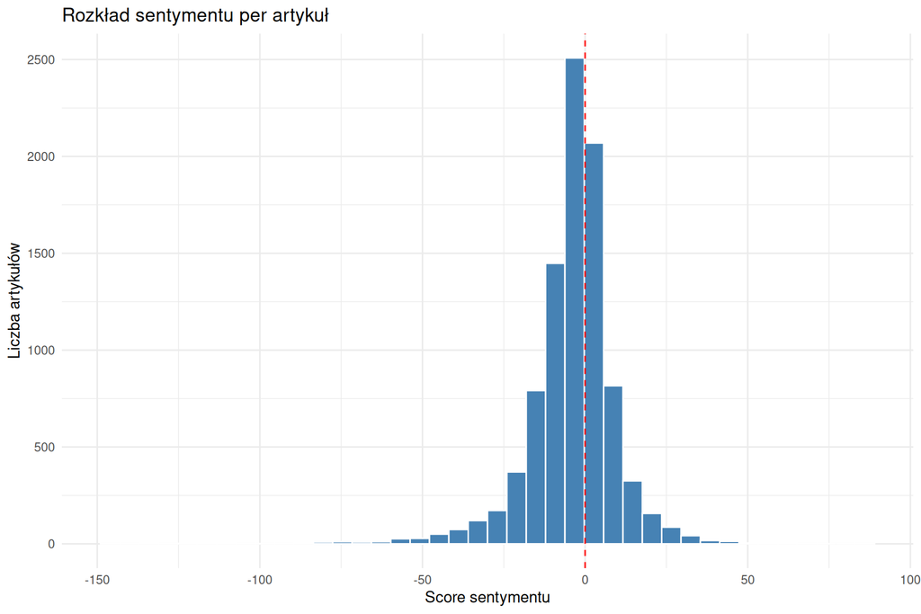

```r
safe_chunk({
  spa <- safe_read_csv(constants$sentiment_per_article, "sentiment_per_article")
  if (is.null(spa)) {
    cat("Brak danych sentiment_per_article.csv.\n")
  } else {
    ggplot(spa, aes(x = score)) +
      geom_histogram(bins = 40, fill = "steelblue", color = "white") +
      geom_vline(xintercept = 0, linetype = "dashed", color = "red") +
      labs(
        title = "Rozkład sentymentu per artykuł",
        x = "Score sentymentu",
        y = "Liczba artykułów"
      ) +
      theme_minimal()
  }
})
```

```r
safe_chunk({
  spa <- safe_read_csv(constants$sentiment_per_article, "sentiment_per_article")
  if (is.null(spa)) {
    cat("Brak danych.\n")
  } else {
    extremes <- bind_rows(
      spa %>% arrange(desc(score)) %>% head(10) %>% mutate(kategoria = "Top 10 pozytywnych"),
      spa %>% arrange(score) %>% head(10) %>% mutate(kategoria = "Top 10 negatywnych")
    )
    DT::datatable(
      extremes,
      filter = "top",
      options = list(pageLength = 10, scrollX = TRUE),
      rownames = FALSE
    )
  }
})
```

| article_id | score | n_pos | n_neg | n_uncertainty | n_litigious | n_constraining | top_pos_words | top_neg_words | kategoria |
| --- | --- | --- | --- | --- | --- | --- | --- | --- | --- |
| edb89ccea656b5e267075e73d8e2b754 | 86 | 138 | 52 | 12 | 10 | 4 | rozwój;zysk;przychód;osiągnąć;rosnąć | problem;pojawić;założenie;blokada;borykać | Top 10 pozytywnych |
| a04b7863ced38d54d40673674dcd7768 | 66 | 76 | 10 | 1 | 3 | 1 | rozwój;wzrost;przychód;zysk;akwizycja | zarządzanie;nacisk;przewidywać;rosnąć;sprzedawca | Top 10 pozytywnych |
| ec4bf01125e43633c5260ea7dec7e0f4 | 61 | 74 | 13 | 3 | 2 | 1 | wzrost;rozwój;przychód;rekordowy;zysk | potwierdzać;ukierunkować;nacisk;negatywny;odpis | Top 10 pozytywnych |
| ca9cc59d68ae859d4e839f6756ee5122 | 60 | 92 | 32 | 10 | 3 | 0 | przychód;rentowność;zysk;wzrost;poprawa | dług;zadłużenie;obniżyć;przewidywać;błąd | Top 10 pozytywnych |
| 3ea676f7a0777918190356f031184354 | 57 | 65 | 8 | 0 | 4 | 0 | wzrost;zysk;przychód;pozytywny;dynamika | zgłaszać;średni;negatywny;spadek | Top 10 pozytywnych |
| 8960fe85a4309dd1f1d0dcca5ffcb69a | 54 | 70 | 16 | 5 | 2 | 2 | przychód;wzrost;zysk;rosnąć;lider | przeliczenie;spadek;możliwy;nieco;niezależnie | Top 10 pozytywnych |
| 29aeff7de4c45e03929ed2e0ca8d4474 | 53 | 72 | 19 | 0 | 7 | 2 | wykonać;udzielać;pozytywnie;zysk;rozwój | spać;statut;niniejszy;para;strata | Top 10 pozytywnych |
| 532add75f26da35faf3e9c2c529f2bd8 | 53 | 67 | 14 | 4 | 0 | 2 | wzrost;przychód;rozwój;inwestycja;silny | nacisk;niewystarczający;przewidywać;brak;deficyt | Top 10 pozytywnych |
| bb3b77857bee5e1f716c084abcd1bf2b | 50 | 58 | 8 | 1 | 2 | 0 | współpraca;wzrost;rozwój;dobry;akwizycja | przenieść;analizować;dlatego;przedmiot;słaby | Top 10 pozytywnych |
| 6a630ff395681303136cbb618bc9b536 | 48 | 77 | 29 | 13 | 6 | 1 | wzrost;inwestycja;przychód;dobry;rozwój | inflacja;daleko;przewidywać;czynić;dlatego | Top 10 pozytywnych |

[output cut: 10 more lines]

## 4.6 Sentyment GPW w czasie

Linia trendu sentymentu medialnego w czasie - granularność tygodniowa (parametr `sentiment_timeline_granularity` w `constants.R`). Linia wygładzona (`geom_smooth`) pokazuje średnioterminowy trend.

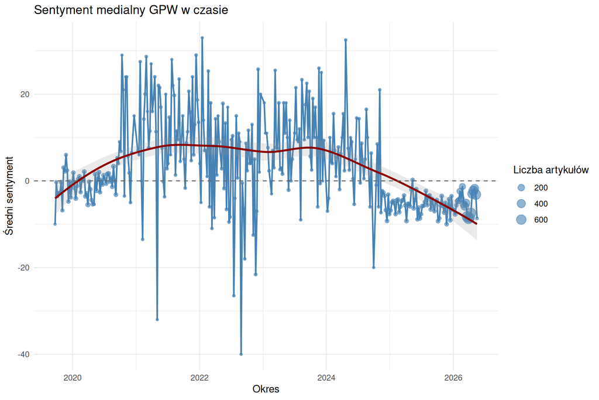

```r
safe_chunk({
  st <- safe_read_csv(constants$sentiment_timeline, "sentiment_timeline")
  if (is.null(st)) {
    cat("Brak danych sentiment_timeline.csv.\n")
  } else {
    st <- st %>% mutate(period = suppressWarnings(as.Date(period)))

    ggplot(st, aes(x = period, y = mean_score)) +
      geom_line(color = "steelblue", linewidth = 0.8) +
      geom_point(aes(size = n_articles), color = "steelblue", alpha = 0.6) +
      geom_smooth(method = "loess", se = TRUE, color = "darkred", alpha = 0.2) +
      geom_hline(yintercept = 0, linetype = "dashed", color = "gray40") +
      scale_size_continuous(range = c(1, 5)) +
      labs(
        title = "Sentyment medialny GPW w czasie",
        x = "Okres",
        y = "Średni sentyment",
        size = "Liczba artykułów"
      ) +
      theme_minimal()
  }
})
```

### 4.6.1 Sentyment vs główne tematy w czasie

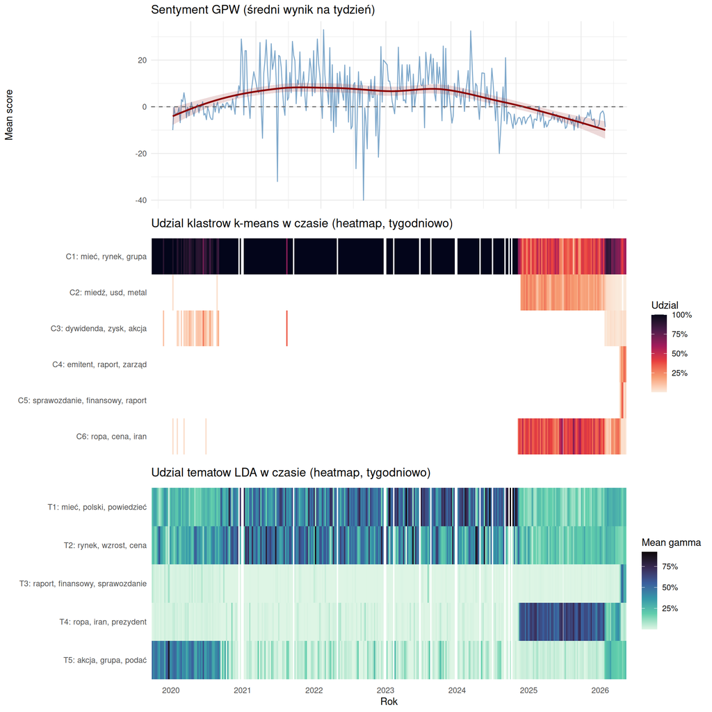

```r
safe_chunk({
  library(lubridate)
  dates <- safe_read_csv(constants$article_dates, "article_dates")
  sent <- safe_read_csv(constants$sentiment_per_article, "sentiment_per_article")
  km <- safe_read_csv(constants$kmeans_assignments, "kmeans_assignments")
  km_words <- safe_read_csv(constants$kmeans_words_per_cluster, "kmeans_words_per_cluster")
  gamma <- safe_read_csv(constants$article_topic_gamma, "article_topic_gamma")
  topics <- safe_read_csv(constants$topics_lda, "topics_lda")
  if (is.null(dates) || is.null(sent) || is.null(km)) {
    cat("Brak danych do zestawienia sentyment vs tematy.\n")
  } else {
    cluster_labels <- km_words %>%
      group_by(cluster) %>%
      slice_max(n, n = 3, with_ties = FALSE) %>%
      summarise(label = sprintf("C%d: %s", first(cluster),
                                paste(word, collapse = ", ")), .groups = "drop")

    merged <- sent %>%
      inner_join(dates, by = "article_id") %>%
      inner_join(km, by = "article_id") %>%
      mutate(
        date = suppressWarnings(ymd_hm(publication_date, quiet = TRUE)),
        date = as.Date(date),
        period = floor_date(date, "week")
      ) %>%
      filter(!is.na(period))

    sent_w <- merged %>%
      group_by(period) %>%
      summarise(mean_score = mean(score, na.rm = TRUE),
                n = dplyr::n(), .groups = "drop")

    cluster_share <- merged %>%
      count(period, cluster, name = "n_in_cluster") %>%
      group_by(period) %>%
      mutate(share = n_in_cluster / sum(n_in_cluster)) %>%
      ungroup() %>%
      left_join(cluster_labels, by = "cluster") %>%
      mutate(label = factor(label, levels = rev(cluster_labels$label)))

    date_range <- range(merged$period, na.rm = TRUE)

    p1 <- ggplot(sent_w, aes(x = period, y = mean_score)) +
      geom_line(color = "steelblue", linewidth = 0.5, alpha = 0.7) +
      geom_smooth(method = "loess", se = TRUE, color = "darkred",
                  fill = "darkred", alpha = 0.15, linewidth = 0.9) +
      geom_hline(yintercept = 0, linetype = "dashed", color = "gray40") +
      scale_x_date(limits = date_range, date_breaks = "1 year", date_labels = "%Y") +
      labs(title = "Sentyment GPW (średni wynik na tydzień)",
           x = NULL, y = "Mean score") +
      theme_minimal(base_size = 11) +
      theme(axis.text.x = element_blank(), axis.ticks.x = element_blank())

    p2 <- ggplot(cluster_share, aes(x = period, y = label, fill = share)) +
      geom_tile() +
      scale_fill_viridis_c(option = "rocket", direction = -1,
                           labels = scales::percent_format(accuracy = 1)) +
      scale_x_date(limits = date_range, date_breaks = "1 year", date_labels = "%Y",
                   expand = c(0, 0)) +
      labs(title = "Udzial klastrow k-means w czasie (heatmap, tygodniowo)",
           x = NULL, y = NULL, fill = "Udzial") +
      theme_minimal(base_size = 11) +
      theme(panel.grid = element_blank(),
            axis.text.x = element_blank(),
            axis.ticks.x = element_blank(),
            legend.position = "right")

    # LDA topic shares - mean gamma per topic per period
    lda_share <- merged %>%
      select(article_id, period) %>%
      inner_join(gamma, by = "article_id") %>%
      group_by(period, topic) %>%
      summarise(mean_gamma = mean(gamma), .groups = "drop")

    lda_labels <- topics %>%
      group_by(topic) %>%
      slice_max(beta, n = 3, with_ties = FALSE) %>%
      summarise(label = sprintf("T%d: %s", first(topic),
                                paste(term, collapse = ", ")), .groups = "drop")

    lda_share <- lda_share %>%
      left_join(lda_labels, by = "topic") %>%
      mutate(label = factor(label, levels = rev(lda_labels$label)))

    p3 <- ggplot(lda_share, aes(x = period, y = label, fill = mean_gamma)) +
      geom_tile() +
      scale_fill_viridis_c(option = "mako", direction = -1,
                           labels = scales::percent_format(accuracy = 1)) +
      scale_x_date(limits = date_range, date_breaks = "1 year", date_labels = "%Y",
                   expand = c(0, 0)) +
      labs(title = "Udzial tematow LDA w czasie (heatmap, tygodniowo)",
           x = "Rok", y = NULL, fill = "Mean gamma") +
      theme_minimal(base_size = 11) +
      theme(panel.grid = element_blank(),
            legend.position = "right")

    if (requireNamespace("cowplot", quietly = TRUE)) {
      cowplot::plot_grid(p1, p2, p3, ncol = 1, align = "v",
                         rel_heights = c(0.3, 0.35, 0.35))
    } else {
      print(p1); print(p2); print(p3)
    }
  }
})
```

### 4.6.2 Dominujący temat per miesiąc (k-means + LDA)

Dla każdego miesiąca dominujący klaster k-means (z top słowami) oraz dominujący LDA topic (z top słowami). Pozwala szybko prześledzić “o czym pisał się rynek” miesiąc po miesiącu.

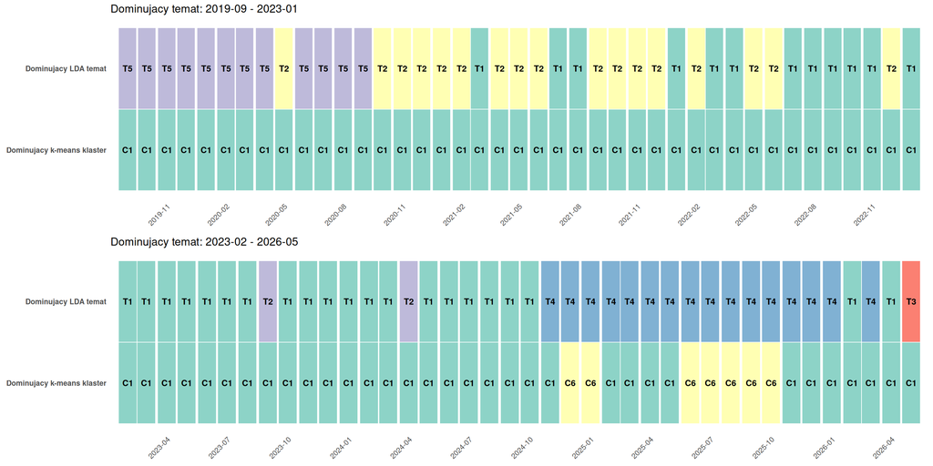

```r
safe_chunk({
  library(lubridate)
  dates <- safe_read_csv(constants$article_dates, "article_dates")
  km <- safe_read_csv(constants$kmeans_assignments, "kmeans_assignments")
  km_words <- safe_read_csv(constants$kmeans_words_per_cluster, "kmeans_words_per_cluster")
  gamma <- safe_read_csv(constants$article_topic_gamma, "article_topic_gamma")
  topics <- safe_read_csv(constants$topics_lda, "topics_lda")
  if (is.null(dates) || is.null(km) || is.null(km_words) || is.null(gamma) || is.null(topics)) {
    cat("Brak danych.\n")
  } else {
    km_labels <- km_words %>%
      group_by(cluster) %>%
      slice_max(n, n = 3, with_ties = FALSE) %>%
      summarise(km_label = paste(word, collapse = ", "), .groups = "drop")

    lda_labels <- topics %>%
      group_by(topic) %>%
      slice_max(beta, n = 3, with_ties = FALSE) %>%
      summarise(lda_label = paste(term, collapse = ", "), .groups = "drop")

    article_period <- dates %>%
      mutate(date = suppressWarnings(ymd_hm(publication_date, quiet = TRUE)),
             date = as.Date(date),
             period = floor_date(date, "month")) %>%
      filter(!is.na(period)) %>%
      select(article_id, period)

    # No agressive filter - drop only months with <3 articles (single-article noise).
    n_per_month <- article_period %>% count(period, name = "n_articles")
    good_periods <- n_per_month %>% filter(n_articles >= 3) %>% pull(period)

    dom_km <- article_period %>%
      filter(period %in% good_periods) %>%
      inner_join(km, by = "article_id") %>%
      count(period, cluster) %>%
      group_by(period) %>%
      slice_max(n, n = 1, with_ties = FALSE) %>%
      ungroup() %>%
      left_join(km_labels, by = "cluster") %>%
      mutate(row = "Dominujacy k-means klaster",
             label = sprintf("C%d", cluster))

    dom_lda <- article_period %>%
      filter(period %in% good_periods) %>%
      inner_join(gamma, by = "article_id") %>%
      group_by(period, topic) %>%
      summarise(mean_gamma = mean(gamma), .groups = "drop") %>%
      group_by(period) %>%
      slice_max(mean_gamma, n = 1, with_ties = FALSE) %>%
      ungroup() %>%
      left_join(lda_labels, by = "topic") %>%
      mutate(row = "Dominujacy LDA temat",
             label = sprintf("T%d", topic))

    combined <- bind_rows(
      dom_km %>% transmute(period, row, label, value = factor(cluster)),
      dom_lda %>% transmute(period, row, label, value = factor(topic))
    )

    # Split into two halves by date so each tile gets ~2x more horizontal space.
    median_date <- as.Date(median(as.numeric(combined$period), na.rm = TRUE),
                           origin = "1970-01-01")
    p_top <- combined %>% filter(period <= median_date)
    p_bot <- combined %>% filter(period > median_date)

    make_panel <- function(df, title_suffix) {
      ggplot(df, aes(x = period, y = row, fill = value)) +
        geom_tile(color = "white", linewidth = 0.3) +
        geom_text(aes(label = label), size = 3.2, fontface = "bold") +
        scale_fill_brewer(palette = "Set3", guide = "none") +
        scale_x_date(date_breaks = "3 months", date_labels = "%Y-%m",
                     expand = c(0.01, 0.01)) +
        labs(title = title_suffix, x = NULL, y = NULL) +
        theme_minimal(base_size = 10) +
        theme(panel.grid = element_blank(),
              axis.text.y = element_text(face = "bold"),
              axis.text.x = element_text(angle = 45, hjust = 1, size = 8))
    }

    pA <- make_panel(p_top, sprintf("Dominujacy temat: %s - %s",
                                    format(min(p_top$period), "%Y-%m"),
                                    format(max(p_top$period), "%Y-%m")))
    pB <- make_panel(p_bot, sprintf("Dominujacy temat: %s - %s",
                                    format(min(p_bot$period), "%Y-%m"),
                                    format(max(p_bot$period), "%Y-%m")))

    if (requireNamespace("cowplot", quietly = TRUE)) {
      print(cowplot::plot_grid(pA, pB, ncol = 1, align = "v"))
    } else {
      print(pA); print(pB)
    }
  }
})
```

```r
safe_chunk({
  km_words <- safe_read_csv(constants$kmeans_words_per_cluster, "kmeans_words_per_cluster")
  topics <- safe_read_csv(constants$topics_lda, "topics_lda")
  if (!is.null(km_words) && !is.null(topics)) {
    km_labels <- km_words %>%
      group_by(cluster) %>%
      slice_max(n, n = 3, with_ties = FALSE) %>%
      summarise(km_label = paste(word, collapse = ", "), .groups = "drop")
    lda_labels <- topics %>%
      group_by(topic) %>%
      slice_max(beta, n = 3, with_ties = FALSE) %>%
      summarise(lda_label = paste(term, collapse = ", "), .groups = "drop")

    cat("Legenda klastrów k-means:\n\n")
    for (i in seq_len(nrow(km_labels))) {
      cat(sprintf("- C%d: %s\n", km_labels$cluster[i], km_labels$km_label[i]))
    }
    cat("\nLegenda tematów LDA:\n\n")
    for (i in seq_len(nrow(lda_labels))) {
      cat(sprintf("- T%d: %s\n", lda_labels$topic[i], lda_labels$lda_label[i]))
    }
  }
})
```

Legenda klastrów k-means:

- C1: mieć, rynek, grupa
- C2: miedź, usd, metal
- C3: dywidenda, zysk, akcja
- C4: emitent, raport, zarząd
- C5: sprawozdanie, finansowy, raport
- C6: ropa, cena, iran

Legenda tematów LDA:

- T1: mieć, polski, powiedzieć
- T2: rynek, wzrost, cena
- T3: raport, finansowy, sprawozdanie
- T4: ropa, iran, prezydent
- T5: akcja, grupa, podać

### 4.6.3 Sentyment medialny vs notowania WIG20

Porównanie sentymentu medialnego z faktyczną ceną indeksu WIG20 (tygodniowe close). Jeśli sentyment medialny ma jakąś moc prognozującą lub współbieżną z rynkiem, powinniśmy widzieć korelację - wahania sentymentu nakładające się na ruchy ceny.

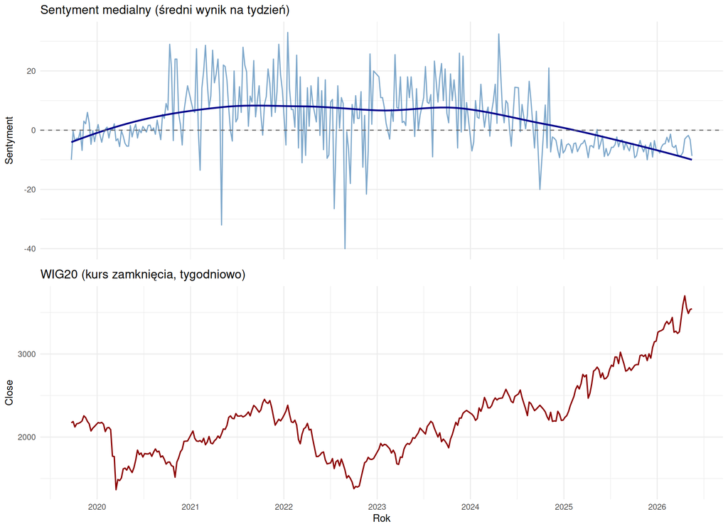

```r
safe_chunk({
  library(lubridate)
  wig <- safe_read_csv(constants$wig20_weekly_path, "wig20_w")
  st <- safe_read_csv(constants$sentiment_timeline, "sentiment_timeline")
  if (is.null(wig) || is.null(st)) {
    cat("Brak danych do zestawienia WIG20 vs sentyment.\n")
  } else {
    wig <- wig %>%
      mutate(date = as.Date(Data),
             period = floor_date(date, "week")) %>%
      select(period, wig_close = Zamkniecie, wig_vol = Wolumen)

    sent <- st %>%
      mutate(period = as.Date(period)) %>%
      select(period, mean_score, n_articles)

    # Match on the week period - only weeks where both data exist.
    merged <- inner_join(sent, wig, by = "period") %>%
      arrange(period) %>%
      mutate(
        wig_return = (wig_close / lag(wig_close) - 1) * 100,
        sent_lag1 = lag(mean_score)
      )

    p1 <- ggplot(merged, aes(x = period)) +
      geom_line(aes(y = mean_score), color = "steelblue", linewidth = 0.6, alpha = 0.7) +
      geom_smooth(aes(y = mean_score), method = "loess", se = FALSE,
                  color = "darkblue", linewidth = 0.9) +
      geom_hline(yintercept = 0, linetype = "dashed", color = "gray40") +
      labs(title = "Sentyment medialny (średni wynik na tydzień)",
           x = NULL, y = "Sentyment") +
      theme_minimal(base_size = 11) +
      theme(axis.text.x = element_blank(), axis.ticks.x = element_blank())

    p2 <- ggplot(merged, aes(x = period, y = wig_close)) +
      geom_line(color = "darkred", linewidth = 0.7) +
      scale_x_date(date_breaks = "1 year", date_labels = "%Y") +
      labs(title = "WIG20 (kurs zamknięcia, tygodniowo)",
           x = "Rok", y = "Close") +
      theme_minimal(base_size = 11)

    if (requireNamespace("cowplot", quietly = TRUE)) {
      print(cowplot::plot_grid(p1, p2, ncol = 1, align = "v",
                               rel_heights = c(0.5, 0.5)))
    } else {
      print(p1); print(p2)
    }
  }
})
```

```r
safe_chunk({
  library(lubridate)
  wig <- safe_read_csv(constants$wig20_weekly_path, "wig20_w")
  st <- safe_read_csv(constants$sentiment_timeline, "sentiment_timeline")
  if (is.null(wig) || is.null(st)) {
    cat("Brak danych.\n")
  } else {
    wig <- wig %>%
      mutate(period = floor_date(as.Date(Data), "week")) %>%
      select(period, wig_close = Zamkniecie)
    sent <- st %>% mutate(period = as.Date(period)) %>% select(period, mean_score)
    merged <- inner_join(sent, wig, by = "period") %>%
      arrange(period) %>%
      mutate(wig_return = (wig_close / lag(wig_close) - 1) * 100,
             sent_lag1 = lag(mean_score))

    cor_concurrent <- cor(merged$mean_score, merged$wig_return,
                          use = "complete.obs", method = "spearman")
    cor_lagged <- cor(merged$sent_lag1, merged$wig_return,
                      use = "complete.obs", method = "spearman")

    cat(sprintf("Tygodni z danymi z obu źródeł: %d (zakres %s - %s).\n\n",
                nrow(merged), min(merged$period), max(merged$period)))
    cat("Korelacja Spearmana (sentyment vs tygodniowa stopa zwrotu WIG20):\n\n")
    cat(sprintf("- Współbieżna (ten sam tydzień): rho = %.3f\n", cor_concurrent))
    cat(sprintf("- Z opóźnieniem 1 tygodnia (sentyment poprzedniego tygodnia vs zwrot): rho = %.3f\n",
                cor_lagged))
    cat("\nBrak istotnej korelacji współbieżnej oznacza, że sentyment medialny ",
        "odzwierciedla zdarzenia już zaszłe, a nie wyprzedza ruchów rynku.\n", sep = "")
  }
})
```

Tygodni z danymi z obu źródeł: 331 (zakres 2019-09-22 - 2026-05-17).

Korelacja Spearmana (sentyment vs tygodniowa stopa zwrotu WIG20):

- Współbieżna (ten sam tydzień): rho = -0.006
- Z opóźnieniem 1 tygodnia (sentyment poprzedniego tygodnia vs zwrot): rho = -0.052

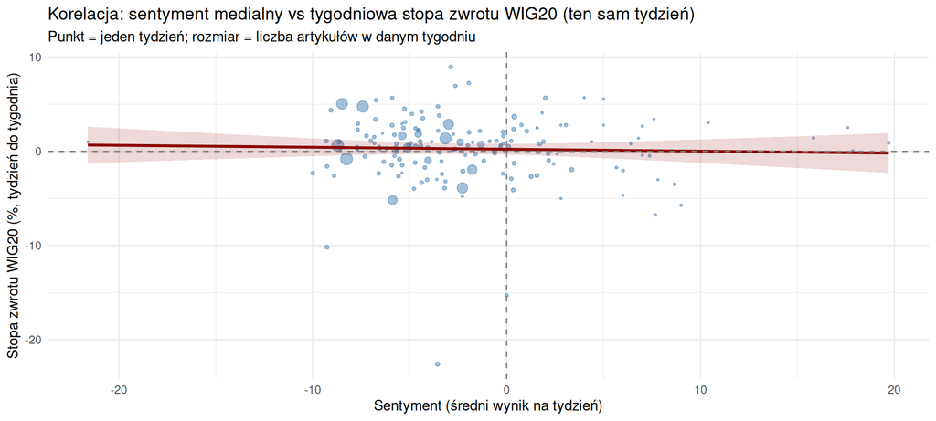

```r
safe_chunk({
  library(lubridate)
  wig <- safe_read_csv(constants$wig20_weekly_path, "wig20_w")
  st <- safe_read_csv(constants$sentiment_timeline, "sentiment_timeline")
  if (is.null(wig) || is.null(st)) {
    cat("Brak danych.\n")
  } else {
    wig <- wig %>%
      mutate(date = as.Date(Data),
             period = floor_date(date, "week")) %>%
      arrange(date) %>%
      mutate(wig_return = (Zamkniecie / lag(Zamkniecie) - 1) * 100) %>%
      select(period, wig_return)

    sent <- st %>% mutate(period = as.Date(period)) %>%
      select(period, mean_score, n_articles)

    merged <- inner_join(sent, wig, by = "period") %>%
      filter(!is.na(wig_return), n_articles >= 5)

    p <- ggplot(merged, aes(x = mean_score, y = wig_return)) +
      geom_point(alpha = 0.5, color = "steelblue", aes(size = n_articles)) +
      geom_smooth(method = "lm", se = TRUE, color = "darkred",
                  fill = "darkred", alpha = 0.15) +
      geom_hline(yintercept = 0, linetype = "dashed", color = "gray50") +
      geom_vline(xintercept = 0, linetype = "dashed", color = "gray50") +
      scale_size_continuous(range = c(0.5, 4), guide = "none") +
      labs(title = "Korelacja: sentyment medialny vs tygodniowa stopa zwrotu WIG20 (ten sam tydzień)",
           subtitle = "Punkt = jeden tydzień; rozmiar = liczba artykułów w danym tygodniu",
           x = "Sentyment (średni wynik na tydzień)",
           y = "Stopa zwrotu WIG20 (%, tydzień do tygodnia)") +
      theme_minimal(base_size = 11)
    print(p)
  }
})
```

# 5 Case study: PKN Orlen

PKN Orlen to najczęściej omawiana spółka w korpusie (340 artykułów, 215 w samym 2026 - mediana 9.5 artykułu/tydzień). Tak gęsty sygnał pozwala zrobić dla pojedynczej spółki to, co dla całego WIG20: zestawić sentyment medialny z faktyczną ceną akcji oraz pokazać, jakie tematy i kategorie napędzają wydźwięk.

## 5.1 Sentyment medialny vs cena akcji PKN

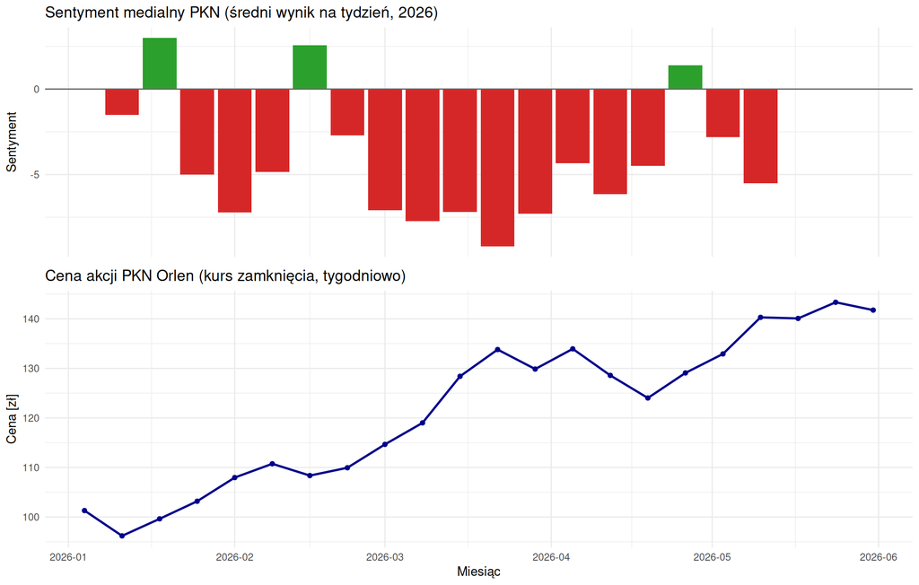

```r
safe_chunk({
  pkn <- load_pkn_2026()
  price <- safe_read_csv(constants$pkn_weekly_path, "pkn_w")
  if (nrow(pkn) == 0 || is.null(price)) {
    cat("Brak danych PKN.\n")
  } else {
    sent_wk <- pkn %>%
      group_by(period) %>%
      summarise(mean_score = mean(score, na.rm = TRUE), n = dplyr::n(), .groups = "drop")

    price <- price %>%
      mutate(period = floor_date(as.Date(Data), "week")) %>%
      select(period, close = Zamkniecie)

    p1 <- ggplot(sent_wk, aes(x = period, y = mean_score)) +
      geom_col(aes(fill = mean_score >= 0), show.legend = FALSE) +
      scale_fill_manual(values = c("TRUE" = "#2ca02c", "FALSE" = "#d62728")) +
      geom_hline(yintercept = 0, color = "gray40") +
      scale_x_date(limits = range(price$period), date_breaks = "1 month", date_labels = "%m") +
      labs(title = "Sentyment medialny PKN (średni wynik na tydzień, 2026)",
           x = NULL, y = "Sentyment") +
      theme_minimal(base_size = 11) +
      theme(axis.text.x = element_blank(), axis.ticks.x = element_blank())

    p2 <- ggplot(price, aes(x = period, y = close)) +
      geom_line(color = "darkblue", linewidth = 0.9) +
      geom_point(color = "darkblue", size = 1.5) +
      scale_x_date(date_breaks = "1 month", date_labels = "%Y-%m") +
      labs(title = "Cena akcji PKN Orlen (kurs zamknięcia, tygodniowo)",
           x = "Miesiąc", y = "Cena [zł]") +
      theme_minimal(base_size = 11)

    if (requireNamespace("cowplot", quietly = TRUE)) {
      print(cowplot::plot_grid(p1, p2, ncol = 1, align = "v", rel_heights = c(0.45, 0.55)))
    } else {
      print(p1); print(p2)
    }
  }
})
```

```r
safe_chunk({
  pkn <- load_pkn_2026()
  price <- safe_read_csv(constants$pkn_weekly_path, "pkn_w")
  if (nrow(pkn) == 0 || is.null(price)) {
    cat("Brak danych.\n")
  } else {
    sent_wk <- pkn %>%
      group_by(period) %>%
      summarise(mean_score = mean(score, na.rm = TRUE), .groups = "drop")
    price <- price %>%
      mutate(period = floor_date(as.Date(Data), "week")) %>%
      arrange(period) %>%
      mutate(ret = (Zamkniecie / lag(Zamkniecie) - 1) * 100) %>%
      select(period, ret)

    merged <- inner_join(sent_wk, price, by = "period") %>%
      arrange(period) %>%
      mutate(sent_lag1 = lag(mean_score))

    cc <- cor(merged$mean_score, merged$ret, use = "complete.obs", method = "spearman")
    cl <- cor(merged$sent_lag1, merged$ret, use = "complete.obs", method = "spearman")

    cat(sprintf("Tygodni z danymi z obu źródeł: %d.\n\n", sum(!is.na(merged$ret))))
    cat("Korelacja Spearmana (sentyment PKN vs tygodniowa stopa zwrotu akcji):\n\n")
    cat(sprintf("- Współbieżna (ten sam tydzień): rho = %.3f\n", cc))
    cat(sprintf("- Z opóźnieniem 1 tygodnia: rho = %.3f\n", cl))
  }
})
```

Tygodni z danymi z obu źródeł: 18.

Korelacja Spearmana (sentyment PKN vs tygodniowa stopa zwrotu akcji):

- Współbieżna (ten sam tydzień): rho = -0.383
- Z opóźnieniem 1 tygodnia: rho = -0.020

## 5.2 Kategorie sentymentu PKN w czasie

Z czego składa się wydźwięk wokół PKN - rozkład kategorii (pozytywny, negatywny, niepewność, prawne, regulacyjne) per tydzień.

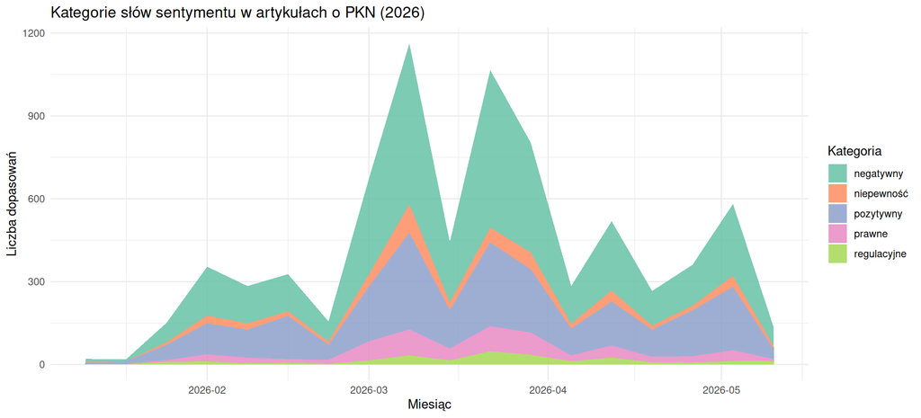

```r
safe_chunk({
  pkn <- load_pkn_2026()
  if (nrow(pkn) == 0) {
    cat("Brak danych.\n")
  } else {
    cat_long <- pkn %>%
      group_by(period) %>%
      summarise(across(c(n_pos, n_neg, n_uncertainty, n_litigious, n_constraining),
                       ~ sum(.x, na.rm = TRUE)), .groups = "drop") %>%
      tidyr::pivot_longer(-period, names_to = "kategoria", values_to = "n") %>%
      mutate(kategoria = recode(kategoria,
        n_pos = "pozytywny", n_neg = "negatywny", n_uncertainty = "niepewność",
        n_litigious = "prawne", n_constraining = "regulacyjne"))

    ggplot(cat_long, aes(x = period, y = n, fill = kategoria)) +
      geom_area(position = "stack", alpha = 0.85) +
      scale_fill_brewer(palette = "Set2") +
      scale_x_date(date_breaks = "1 month", date_labels = "%Y-%m") +
      labs(title = "Kategorie słów sentymentu w artykułach o PKN (2026)",
           x = "Miesiąc", y = "Liczba dopasowań", fill = "Kategoria") +
      theme_minimal(base_size = 11)
  }
})
```

## 5.3 Profil tematyczny PKN

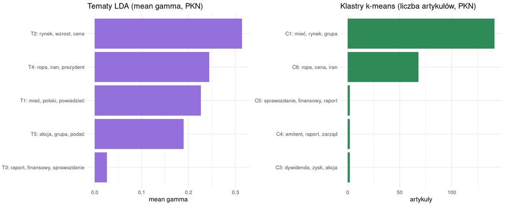

```r
safe_chunk({
  pkn <- load_pkn_2026()
  gamma <- safe_read_csv(constants$article_topic_gamma, "article_topic_gamma")
  topics <- safe_read_csv(constants$topics_lda, "topics_lda")
  km <- safe_read_csv(constants$kmeans_assignments, "kmeans_assignments")
  km_words <- safe_read_csv(constants$kmeans_words_per_cluster, "kmeans_words_per_cluster")
  if (nrow(pkn) == 0 || is.null(gamma) || is.null(km)) {
    cat("Brak danych.\n")
  } else {
    lda_lab <- topics %>% group_by(topic) %>% slice_max(beta, n = 3, with_ties = FALSE) %>%
      summarise(lab = paste(term, collapse = ", "), .groups = "drop") %>%
      mutate(lab = sprintf("T%d: %s", topic, lab))
    pkn_topic <- gamma %>% filter(article_id %in% pkn$article_id) %>%
      group_by(topic) %>% summarise(mean_gamma = mean(gamma), .groups = "drop") %>%
      left_join(lda_lab, by = "topic") %>%
      mutate(lab = factor(lab, levels = lab[order(mean_gamma)]))

    p1 <- ggplot(pkn_topic, aes(x = mean_gamma, y = lab)) +
      geom_col(fill = "mediumpurple") +
      labs(title = "Tematy LDA (mean gamma, PKN)", x = "mean gamma", y = NULL) +
      theme_minimal(base_size = 10)

    km_lab <- km_words %>% group_by(cluster) %>% slice_max(n, n = 3, with_ties = FALSE) %>%
      summarise(lab = paste(word, collapse = ", "), .groups = "drop") %>%
      mutate(lab = sprintf("C%d: %s", cluster, lab))
    pkn_clu <- km %>% filter(article_id %in% pkn$article_id) %>%
      count(cluster, name = "n") %>%
      left_join(km_lab, by = "cluster") %>%
      mutate(lab = factor(lab, levels = lab[order(n)]))

    p2 <- ggplot(pkn_clu, aes(x = n, y = lab)) +
      geom_col(fill = "seagreen") +
      labs(title = "Klastry k-means (liczba artykułów, PKN)", x = "artykuły", y = NULL) +
      theme_minimal(base_size = 10)

    if (requireNamespace("cowplot", quietly = TRUE)) {
      print(cowplot::plot_grid(p1, p2, ncol = 2))
    } else {
      print(p1); print(p2)
    }
  }
})
```

## 5.4 Top słowa sentymentu PKN

Najczęstsze słowa pozytywne (zielone) i negatywne (czerwone) w artykułach o PKN.

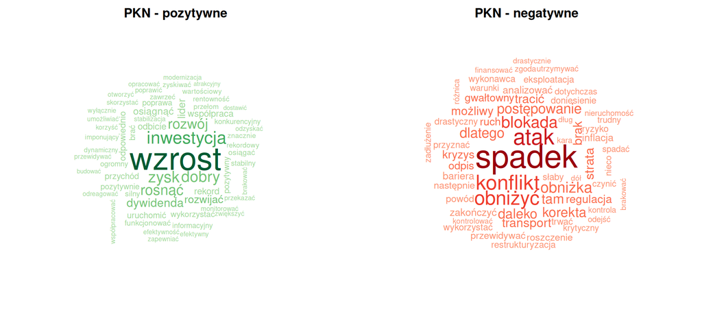

```r
safe_chunk({
  suppressPackageStartupMessages({library(wordcloud); library(RColorBrewer)})
  pkn <- load_pkn_2026()
  if (nrow(pkn) == 0) {
    cat("Brak danych.\n")
  } else {
    split_words <- function(col) {
      w <- unlist(strsplit(col[!is.na(col) & col != ""], ";"))
      tb <- sort(table(w), decreasing = TRUE)
      head(tb, 60)
    }
    pos <- split_words(pkn$top_pos_words)
    neg <- split_words(pkn$top_neg_words)

    par(mfrow = c(1, 2), mar = c(1, 1, 2, 1))
    if (length(pos) > 0) {
      wordcloud(names(pos), as.integer(pos), min.freq = 1, max.words = 60,
                scale = c(3, 0.5), random.order = FALSE,
                colors = brewer.pal(8, "Greens")[4:8])
      title("PKN - pozytywne")
    }
    if (length(neg) > 0) {
      wordcloud(names(neg), as.integer(neg), min.freq = 1, max.words = 60,
                scale = c(3, 0.5), random.order = FALSE,
                colors = brewer.pal(8, "Reds")[4:8])
      title("PKN - negatywne")
    }
  }
})
```

# 6 Klastrowanie (k-means)

Liczba klastrów k = 6 (parametr `sentiment_kmeans_k` w `constants.R`).

W odróżnieniu od LDA (soft clustering - każdy artykuł ma rozkład prawdopodobieństw na tematach), k-means przypisuje każdy artykuł do jednego klastra. Algorytm operuje na macierzy częstości ważonej TF-IDF, a wiersze są normalizowane (L2) - dzięki temu artykuły grupowane są według proporcji słów, a nie długości tekstu (dłuższy artykuł nie trafia automatycznie do innego klastra niż krótki o tej samej tematyce).

## 6.1 Rozmiary klastrów

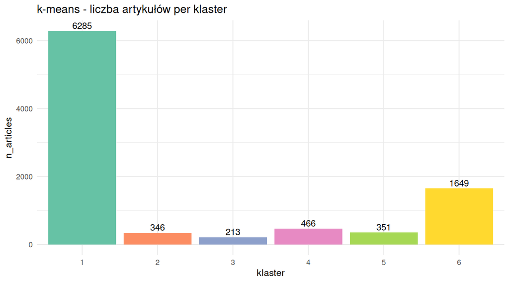

```r
safe_chunk({
  path <- file.path(constants$figures_directory, "kmeans_sizes.png")
  if (file.exists(path)) knitr::include_graphics(path)
  else cat("Brak figury kmeans_sizes.png.\n")
})
```

## 6.2 Top słowa per klaster

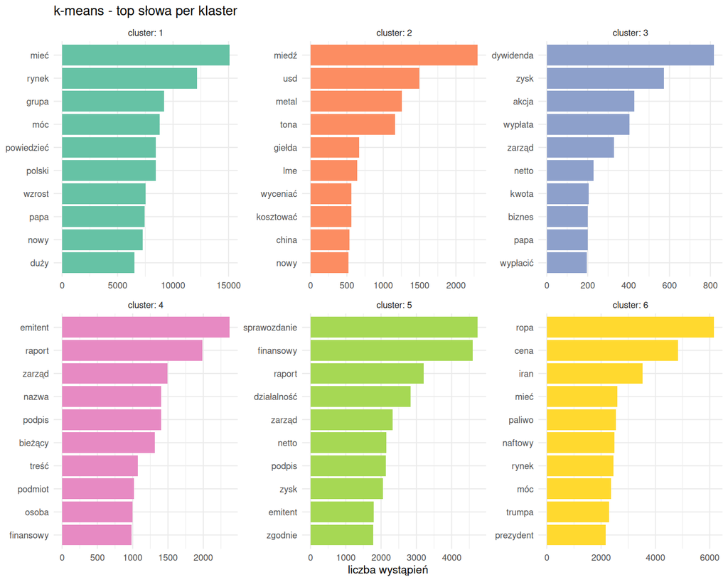

```r
safe_chunk({
  path <- file.path(constants$figures_directory, "kmeans_words.png")
  if (file.exists(path)) knitr::include_graphics(path)
  else cat("Brak figury kmeans_words.png.\n")
})
```

```r
safe_chunk({
  km_words <- safe_read_csv(constants$kmeans_words_per_cluster, "kmeans_words_per_cluster")
  if (is.null(km_words)) {
    cat("Brak danych kmeans_words_per_cluster.csv.\n")
  } else {
    top8 <- km_words %>%
      group_by(cluster) %>%
      slice_max(n, n = 8, with_ties = FALSE) %>%
      summarise(top_words = paste(word, collapse = ", "), .groups = "drop")
    knitr::kable(top8, caption = "Top 8 słów per klaster (k-means)")
  }
})
```

Top 8 słów per klaster (k-means)

| cluster | top_words |
| --- | --- |
| 1 | mieć, rynek, grupa, móc, powiedzieć, polski, wzrost, papa |
| 2 | miedź, usd, metal, tona, giełda, lme, wyceniać, kosztować |
| 3 | dywidenda, zysk, akcja, wypłata, zarząd, netto, kwota, biznes |
| 4 | emitent, raport, zarząd, nazwa, podpis, bieżący, treść, podmiot |
| 5 | sprawozdanie, finansowy, raport, działalność, zarząd, netto, podpis, zysk |
| 6 | ropa, cena, iran, mieć, paliwo, naftowy, rynek, móc |

## 6.3 Chmury słów per klaster

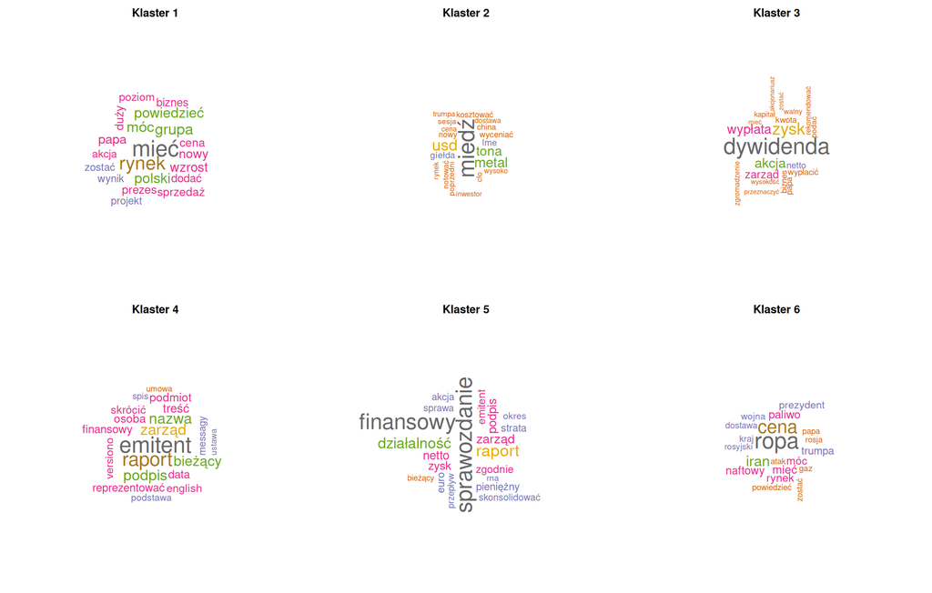

```r
safe_chunk({
  suppressPackageStartupMessages({library(wordcloud); library(RColorBrewer)})
  km_words <- safe_read_csv(constants$kmeans_words_per_cluster, "kmeans_words_per_cluster")
  if (is.null(km_words)) {
    cat("Brak danych kmeans_words_per_cluster.csv.\n")
  } else {
    clusters <- sort(unique(km_words$cluster))
    ncol_grid <- 3
    nrow_grid <- ceiling(length(clusters) / ncol_grid)
    par(mfrow = c(nrow_grid, ncol_grid), mar = c(0.5, 0.5, 2, 0.5))
    for (cl in clusters) {
      sub <- km_words[km_words$cluster == cl, ]
      sub <- sub[order(-sub$n), ]
      tryCatch({
        wordcloud(sub$word, sub$n, min.freq = 1, max.words = 40,
                  scale = c(2.4, 0.4), random.order = FALSE, rot.per = 0.15,
                  colors = brewer.pal(8, "Dark2"))
        title(sprintf("Klaster %d", cl), line = 0.5)
      }, error = function(e) { plot.new(); title(sprintf("Klaster %d (err)", cl)) })
    }
  }
})
```

# 7 Topic modeling (LDA)

Liczba tematów k = 5 (parametr `sentiment_lda_k` w `constants.R`).

## 7.1 Top słowa per temat

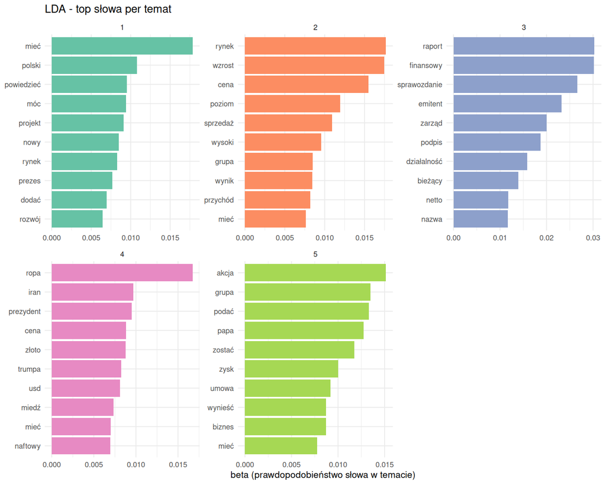

```r
safe_chunk({
  path <- file.path(constants$figures_directory, "topics_lda.png")
  if (file.exists(path)) {
    knitr::include_graphics(path)
  } else {
    topics <- safe_read_csv(constants$topics_lda, "topics_lda")
    if (is.null(topics)) {
      cat("Brak danych topics_lda.csv ani figury topics_lda.png.\n")
    } else {
      top_per_topic <- topics %>%
        group_by(topic) %>%
        slice_max(beta, n = 10) %>%
        ungroup() %>%
        mutate(term = reorder(term, beta))

      ggplot(top_per_topic, aes(x = term, y = beta, fill = factor(topic))) +
        geom_col(show.legend = FALSE) +
        facet_wrap(~ topic, scales = "free_y") +
        coord_flip() +
        labs(
          title = "Top 10 słów per temat (LDA)",
          x = NULL,
          y = "Beta"
        ) +
        theme_minimal()
    }
  }
})
```

```r
safe_chunk({
  topics <- safe_read_csv(constants$topics_lda, "topics_lda")
  if (is.null(topics)) {
    cat("Brak danych.\n")
  } else {
    top5 <- topics %>%
      group_by(topic) %>%
      slice_max(beta, n = 5) %>%
      summarise(top_words = paste(term, collapse = ", "), .groups = "drop")
    knitr::kable(top5, caption = "Top 5 słów per temat")
  }
})
```

Top 5 słów per temat

| topic | top_words |
| --- | --- |
| 1 | mieć, polski, powiedzieć, móc, projekt |
| 2 | rynek, wzrost, cena, poziom, sprzedaż |
| 3 | raport, finansowy, sprawozdanie, emitent, zarząd |
| 4 | ropa, iran, prezydent, cena, złoto |
| 5 | akcja, grupa, podać, papa, zostać |

## 7.2 Chmury słów per temat LDA

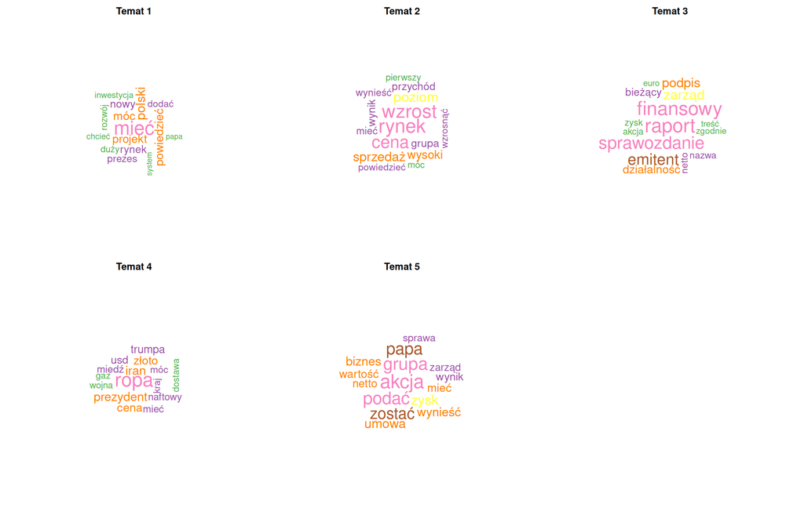

```r
safe_chunk({
  suppressPackageStartupMessages({library(wordcloud); library(RColorBrewer)})
  topics <- safe_read_csv(constants$topics_lda, "topics_lda")
  if (is.null(topics)) {
    cat("Brak danych topics_lda.csv.\n")
  } else {
    tps <- sort(unique(topics$topic))
    ncol_grid <- 3
    nrow_grid <- ceiling(length(tps) / ncol_grid)
    par(mfrow = c(nrow_grid, ncol_grid), mar = c(0.5, 0.5, 2, 0.5))
    for (tp in tps) {
      sub <- topics[topics$topic == tp, ]
      sub <- sub[order(-sub$beta), ]
      tryCatch({
        wordcloud(sub$term, sub$beta, min.freq = 0, max.words = 40,
                  scale = c(2.4, 0.4), random.order = FALSE, rot.per = 0.15,
                  colors = brewer.pal(8, "Set1"))
        title(sprintf("Temat %d", tp), line = 0.5)
      }, error = function(e) { plot.new(); title(sprintf("Temat %d (err)", tp)) })
    }
  }
})
```

## 7.3 Rozkład przynależności artykułów do tematów

Każdy artykuł ma rozkład prawdopodobieństw (gamma) nad tematami. Przypisujemy go do tematu o najwyższej gammie (“temat dominujący”). Lewy panel pokazuje, ile artykułów dominuje każdy temat; prawy - jak pewne są te przypisania (im wyższa gamma, tym silniej artykuł należy do jednego tematu).

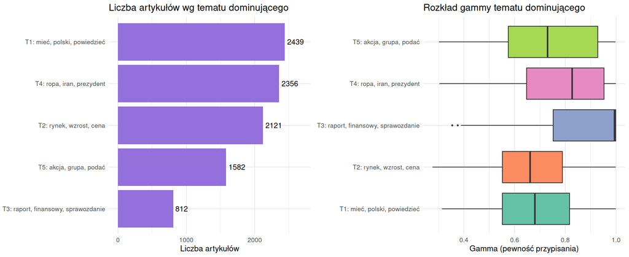

```r
safe_chunk({
  gamma <- safe_read_csv(constants$article_topic_gamma, "article_topic_gamma")
  topics <- safe_read_csv(constants$topics_lda, "topics_lda")
  if (is.null(gamma) || is.null(topics)) {
    cat("Brak danych.\n")
  } else {
    lda_lab <- topics %>%
      group_by(topic) %>%
      slice_max(beta, n = 3, with_ties = FALSE) %>%
      summarise(lab = paste(term, collapse = ", "), .groups = "drop") %>%
      mutate(lab = sprintf("T%d: %s", topic, lab))

    dominant <- gamma %>%
      group_by(article_id) %>%
      slice_max(gamma, n = 1, with_ties = FALSE) %>%
      ungroup()

    counts <- dominant %>%
      count(topic, name = "n") %>%
      left_join(lda_lab, by = "topic") %>%
      mutate(lab = factor(lab, levels = lab[order(n)]))

    p1 <- ggplot(counts, aes(x = n, y = lab)) +
      geom_col(fill = "mediumpurple") +
      geom_text(aes(label = n), hjust = -0.15, size = 3.3) +
      labs(title = "Liczba artykułów wg tematu dominującego",
           x = "Liczba artykułów", y = NULL) +
      theme_minimal(base_size = 10) +
      expand_limits(x = max(counts$n) * 1.1)

    gamma_lab <- dominant %>%
      left_join(lda_lab, by = "topic") %>%
      mutate(lab = factor(lab, levels = counts$lab))

    p2 <- ggplot(gamma_lab, aes(x = gamma, y = lab, fill = lab)) +
      geom_boxplot(show.legend = FALSE, outlier.size = 0.5) +
      scale_fill_brewer(palette = "Set2") +
      labs(title = "Rozkład gammy tematu dominującego",
           x = "Gamma (pewność przypisania)", y = NULL) +
      theme_minimal(base_size = 10)

    if (requireNamespace("cowplot", quietly = TRUE)) {
      print(cowplot::plot_grid(p1, p2, ncol = 2, rel_widths = c(0.5, 0.5)))
    } else {
      print(p1); print(p2)
    }
  }
})
```

# 8 Profile semantyczne spółek (TF-IDF)

TF-IDF wskazuje, które słowa są charakterystyczne dla danej spółki w odniesieniu do całego korpusu - wysoki TF-IDF = słowo często występuje przy konkretnym tickerze, a rzadko gdzie indziej. To pozwala zobaczyć “o czym pisze się przy danej spółce”.

## 8.1 Globalny TF-IDF (cały korpus)

Globalny widok TF-IDF - każdy artykuł traktowany jako oddzielny dokument, suma TF-IDF po wszystkich artykułach. To pokazuje słowa o największej wadze poza klasykami (które mają wysoki TF ale bardzo niskie IDF → niskie TF-IDF, więc spadają z rankingu).

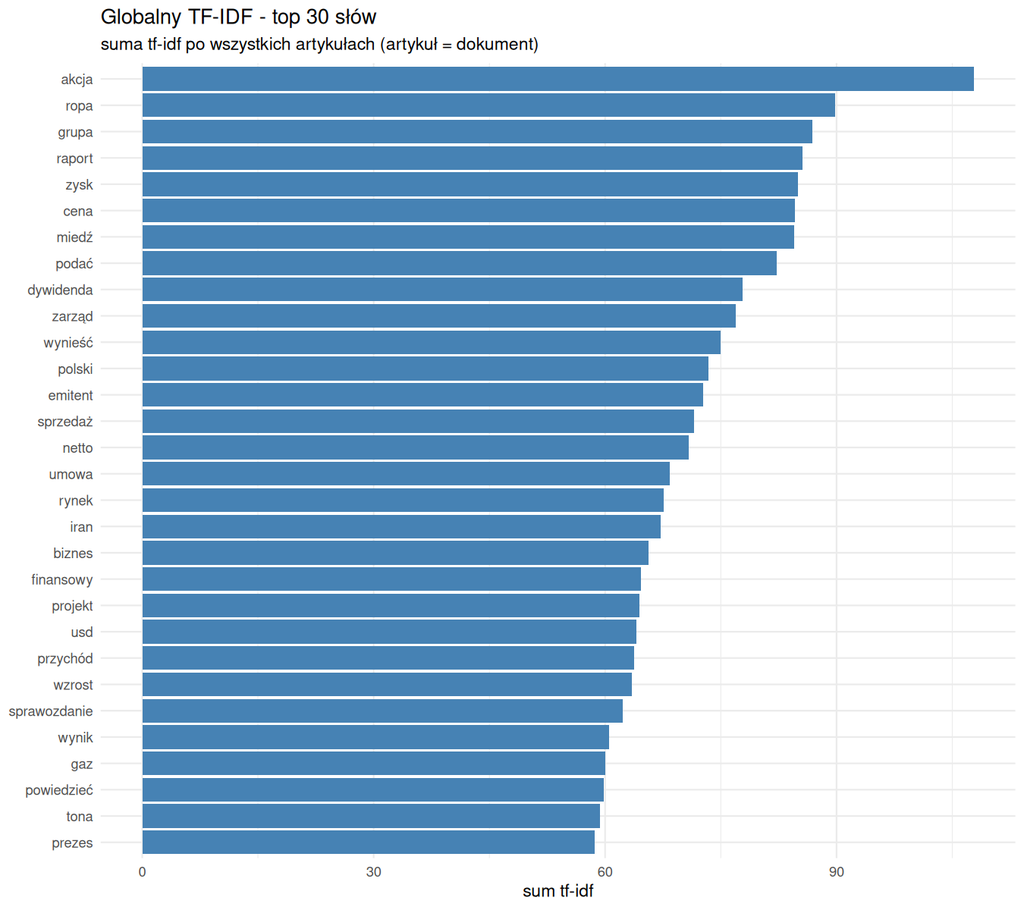

```r
safe_chunk({
  path <- file.path(constants$figures_directory, "tfidf_global.png")
  if (file.exists(path)) knitr::include_graphics(path)
  else cat("Brak figury tfidf_global.png.\n")
})
```

```r
safe_chunk({
  glob <- safe_read_csv(constants$tfidf_global, "tfidf_global")
  if (is.null(glob)) {
    cat("Brak danych tfidf_global.csv.\n")
  } else {
    top20 <- glob %>%
      arrange(desc(sum_tfidf)) %>%
      head(20) %>%
      transmute(word, doc_freq, sum_tfidf = round(sum_tfidf, 2), mean_tfidf = round(mean_tfidf, 4))
    knitr::kable(top20, caption = "Top 20 słów globalnego TF-IDF (poza klasykami)")
  }
})
```

Top 20 słów globalnego TF-IDF (poza klasykami)

| word | doc_freq | sum_tfidf | mean_tfidf |
| --- | --- | --- | --- |
| akcja | 2361 | 107.78 | 0.0457 |
| ropa | 1542 | 89.82 | 0.0582 |
| grupa | 2971 | 86.82 | 0.0292 |
| raport | 2239 | 85.59 | 0.0382 |
| zysk | 2215 | 85.04 | 0.0384 |
| cena | 3231 | 84.62 | 0.0262 |
| miedź | 556 | 84.51 | 0.1520 |
| podać | 3242 | 82.27 | 0.0254 |
| dywidenda | 662 | 77.77 | 0.1175 |
| zarząd | 2218 | 76.96 | 0.0347 |
| wynieść | 2252 | 74.99 | 0.0333 |
| polski | 3124 | 73.41 | 0.0235 |
| emitent | 1024 | 72.67 | 0.0710 |
| sprzedaż | 2519 | 71.58 | 0.0284 |
| netto | 1909 | 70.83 | 0.0371 |
| umowa | 1606 | 68.41 | 0.0426 |
| rynek | 4369 | 67.59 | 0.0155 |
| iran | 1136 | 67.19 | 0.0591 |
| biznes | 4509 | 65.61 | 0.0146 |
| finansowy | 2929 | 64.67 | 0.0221 |